# Econometria de Séries Temporais

João Pedro

2024-03-22

### 1. Introdução a Série Temporal

Principais objetivos em se estudar séries temporais:

- `Descrição:` Descrever propriedades da s ́erie, ou seja, a tendência de longo prazo, componente sazonal, componente cíclicos, observações discrepantes (outliers), alterações estruturais (mudanças no padrão da tendência), etc.
- `Predição`: predizer valores futuros com base em valores passados. Aqui assume-se que o futuro envolve incerteza, ou seja as previsões não são perfeitas.
- `Explicação`: Usar a variação em uma série para explicar a variação de outra série.

#### 1.1 Abordagens para tratar séries temporais

- `Técnicas Descritivas:` Gráficos, identificações de padrões, etc.
- `Métodos não paramétricos:` Decomposição, alisamento ou suavizações.
- `Modelos Probabilísticos:` Seleção, comparação e adequação de modelos, estimações, predições. Ferramentas básicas é a função de autocorrelação e critérios de informações.
- `Outras Abordagens:` Modelos de espaço de estados, modelos não lineares, séries multivariadas, processos de longa dependência, modelos para volatilidade, etc.

#### 1.2 Decomposição Clássica

Considera uma série temporal ${Z_t, t = 1,..., N}$ que pode ser representada como a soma dos componentes:

- `Tendência:` $T_t$, Componente de **Longo Prazo** associado ao movimento da variável no tempo.
- `Ciclo:` $C_t$, Componente de **Médio Prazo** associado a períodos de expansão ou recessão econômica.
- `Sazonalidade:` $S_t$, Componente de **Curto Prazo** associado a variações provocadas por épocas do ano.
- `Resíduos:` $u_t$, Componente que não se pode explicar, aleatório, também denominado **ruído**.

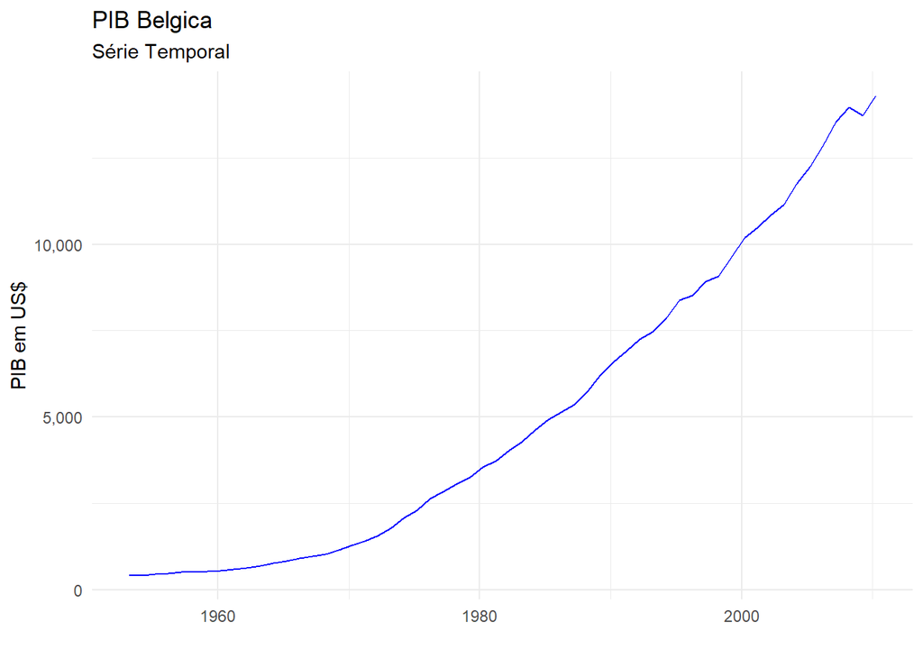

#### 1.3 Tipos de Modelos

- `Aditivo:` Variância estabilizada no tempo **(Homocedástico)**

$$Z_t = T_t + S_t + C_t + u_t$$

- `Multiplicativo:` Variância crescente ao longo do tempo **(Heterocedástico)**

$$Z_t = T_t.S_t.C_t + u_t$$

#### 1.4 Tendência

Supondo que a série $Z_t$ é formada apenas pelos componentes de tendência e o aleatório.

$$Z_t = T_t + u_t$$

em que $\hat u_t$ é o componente aleatório.

Métodos para estimar tendência:

- Ajuste em função do tempo, como um polinômio.
- Suavizar (Filtrar), valores da série, por meio de médias móveis.

##### 1.4.1 Tendência Polinomial

Tendência $T_t$ possa ser representada por um polinômio de ordem $m$, ou seja:

$$T_t = \beta_0 + \beta_1t + \beta_2t^2 +...+ \beta_mt^m$$

Em que $\beta_0, \beta_1,...,\beta_m$ são parâmetros a serem estimados e $t = 1, 2,..., N$ representa o tempo. Para estimar os parâmetros $\beta_j, j = 0, 1,..., m$ usamos o **método dos mínimos quadrados (MQO)**.

Geralmente, uma função linear $m = 1$ ou quadrática $m = 2$ será apropriada para representar uma tendência monotonicamente crescente ou decrescente.

$T_t = \beta_0 + \beta_1t + \beta_2t^2 +...+ \beta_mt^m$ é uma função determinística do tempo, chamada de tendência global. (Vale para toda a série)

#### 1.4.2 Tendência Linear e Previsão

Supondo $T_t = \beta_0 + \beta_1t$ ou seja $m = 1$ temos:

$$Z_t = \beta_0 + \beta_1t + u_t$$

que é um modelo de regressão linear simples, com $Z_t$ a variável dependente e $t$ a variável independente. Aplicando o método de MQO, obtêm-se a série livre de tendência dada por:

$$\hat u_t = Z_t - \hat T_t = Z_t - (\hat \beta_0 + \hat \beta_1t)$$

A partir do modelo de tendência estimado, podemos prever valores da série para o instante $t = N + 1, N + 2, ... N + x$

**Exercício**

Considerando a série anual do PIB - paridade do poder de compra (PPC) - percapita - US$ de 2017, Brasil, período 1980 a 2021, dispon ́ıvel no IPEADATA (arquivo PIB−Brasil.xlsx), faça:

Gráfico da série.

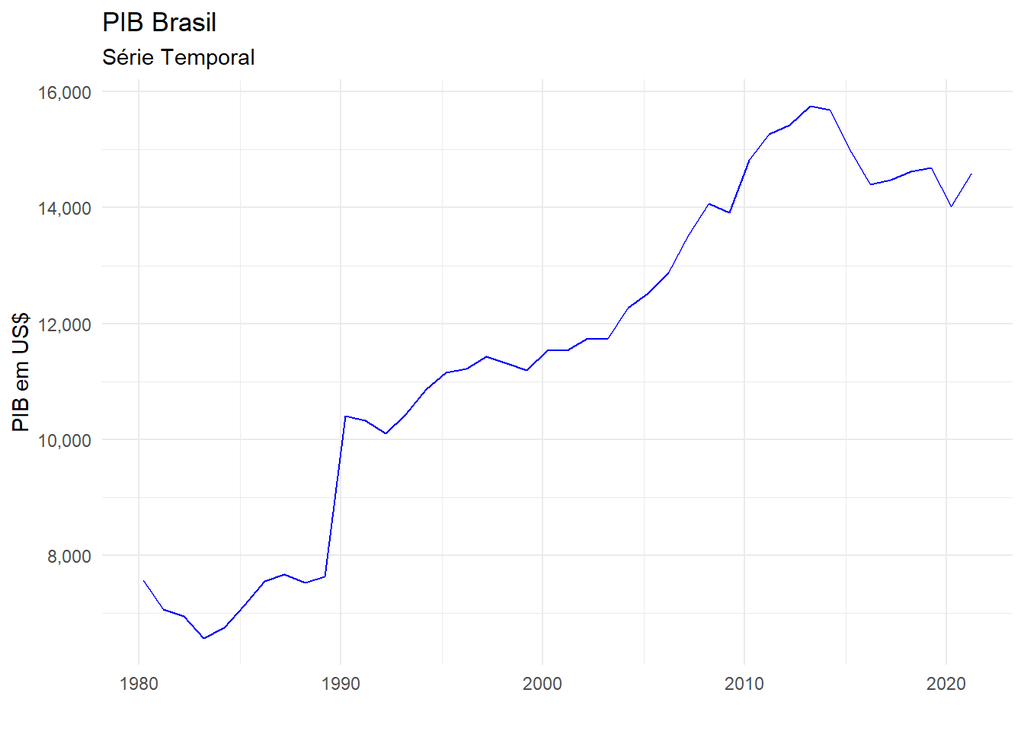

Estime o componente de tendência, supondo que seja linear.

```r
mod.brasil <- lm(pib ~ data, brasil_pib)
summary(mod.brasil)
```

```
##
## Call:
## lm(formula = pib ~ data, data = brasil_pib)
##
## Residuals:
##      Min       1Q   Median       3Q      Max
## -1970.77  -786.85    26.98   688.72  1351.79
##
## Coefficients:
##              Estimate Std. Error t value Pr(>|t|)
## (Intercept) 4.565e+03  3.745e+02   12.19 4.77e-15 ***
## data        6.230e-01  3.105e-02   20.07  < 2e-16 ***
## ---
## Signif. codes:  0 '***' 0.001 '**' 0.01 '*' 0.05 '.' 0.1 ' ' 1
##
## Residual standard error: 890.8 on 40 degrees of freedom
## Multiple R-squared:  0.9096, Adjusted R-squared:  0.9074
## F-statistic: 402.6 on 1 and 40 DF,  p-value: < 2.2e-16
```

```r
trend <- ts(fitted(mod.brasil), start = 1980, freq = 1)
```

Obtenha a série livre de tendência. $PIB - Tendência_{Estimada}$

```r
residual <- ts(residuals(mod.brasil), start = 1980, freq = 1)
```

```r
brasil_pib.ts <- ts(brasil_pib[, 2], start = 1980, end = 2021, frequency = 1)
```

Faça um gráfico com a série original, a série de tendência e a série livre de tendência.

```r
pib_plot <- ggplot(brasil_pib, aes(x = data, y = pib)) +
  geom_line() +
  labs(title = "PIB Brasil", x = NULL, y = "PIB") +
  theme_minimal()

trend_plot <- ggplot(trend, aes(x = brasil_pib$data, y = trend)) +
  geom_line() +
  labs(title = "Trend", x = NULL, y = NULL) +
  theme_minimal()

residual_plot <- ggplot(residual, aes(x = brasil_pib$data, y = residual)) +
  geom_line() +
  labs(title = "Residual", x = NULL, y = NULL) +
  theme_minimal()
```

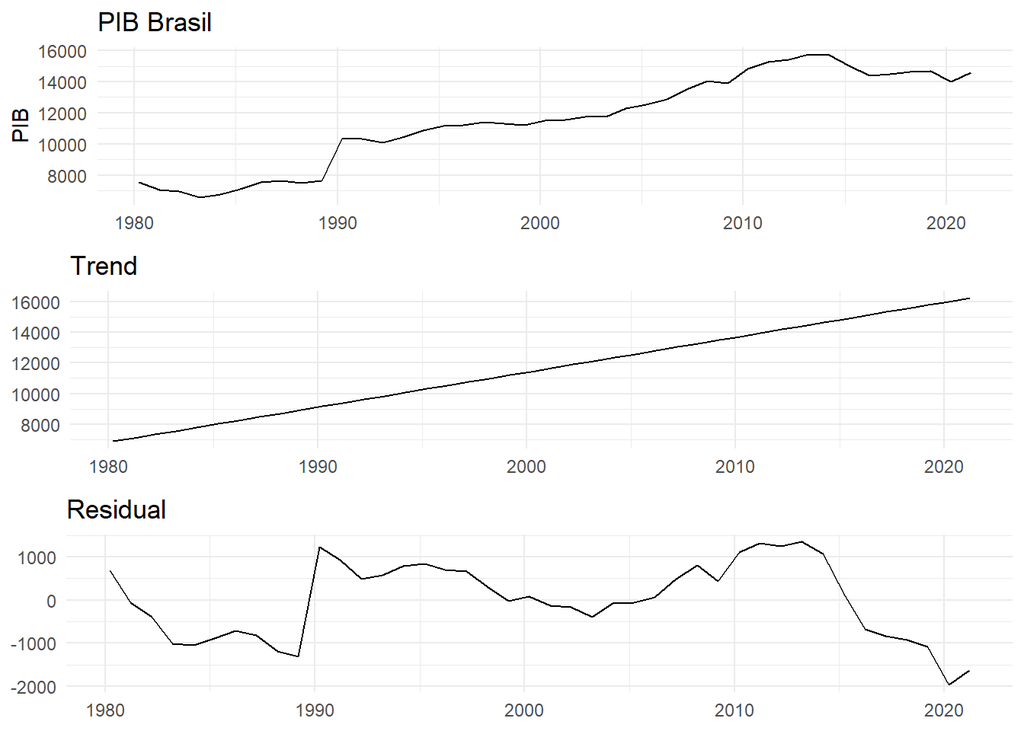

```r
grid.arrange(pib_plot, trend_plot, residual_plot, ncol = 1)
```

Obtenha o valor previsto para o ano de 2022-2024.

```r
# Anos a serem previstos
trend_forecast <- forecast(trend, h = 3)
trend_forecast_values <- trend_forecast$mean

# Criar um dataframe com os dados reais e previstos
df <- data.frame(
  Ano = c(time(brasil_pib.ts), 2022:2024),
  PIB_Real = c(brasil_pib.ts, NA, NA, NA),  # Adicione NA para os anos futuros
  PIB_Previsto = c(rep(NA, length(brasil_pib.ts)), trend_forecast_values))
```

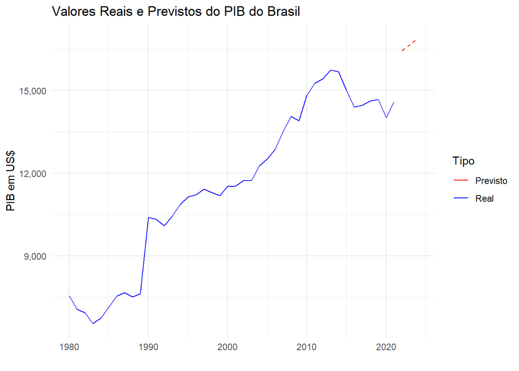

```r
ggplot(df, aes(x = Ano)) +
  geom_line(aes(y = PIB_Real, color = "Real")) +
  geom_line(aes(y = PIB_Previsto, color = "Previsto"), linetype = "dashed") +
  scale_y_continuous(labels = scales::comma) +
  labs(title = "Valores Reais e Previstos do PIB do Brasil",
       y = "PIB em US$",
       color = "Tipo",
       x = "") +
  scale_color_manual(values = c(Real = "blue", Previsto = "red")) +
  theme_minimal()
```

#### 1.5 Sazonalidade

Empiricamente, define-se o componente sazonal como fenômeno que ocorrem regularmente de ano para ano.

Possíveis modelos sazonais:

- `Variáveis Dummies (Binárias):` O coeficiente de cada variável dummy representa o fator sazonal do respectivo mês, ano, etc.
- `Médias Móveis:` Para se obter os fatores sazonais.

##### 1.5.1 Sazonalidade Dummy

Série $Z_t$ seja formada apenas por dois componentes, o de sazonalidade e o aleatório.

$$Z_t = S_t + u_t$$

Série com periodicidade trimestral. Sazonalidade representada pela seguinte regressão.

$$S_t = \beta_0 + \beta_1D_2 + \beta_3D_3 + \beta_4D4$$

Incluimos dummies para cada trimestre, exceto o primeiro, isto para não termos problemas de lineariedade perfeita. Isso também significa que todos os efeitos medidos por $D_i$, serão relativos ao primeiro trimestre.

##### 1.5.1.1 Removendo Sazonalidade por Meio de Dummies

Ajustada a regrssão por MQO podemos fazer um teste F para verificarmos se a presença de uma sazonalidade trimestral ́e significativamente diferente de zero.

A rejeição da hipótese nula significa que a série $Y_t$ apresenta sazonalidade.

O modelo pode ser representado por:

$$Z_t = \hat S_t + \hat u_t$$

A série original $Z_t$ menos a parte que capta os efeitos de sazonalidade $S_t$ é igual a parte “Fitlrada” da série, ou seja, a série dessazonalizada $Z^{SA}$

$$\hat u_t = Z^{SA}_t = Z_t - \hat S_t$$

**Exercício**

```r
# Criar a série temporal
desemp_ts <- ts(desemp[, 2], start = c(1985, 1), freq = 12)

# Criar variáveis sazonais
dummies <- seasonaldummy(desemp_ts)

# Ajustar modelo de regressão linear
mod.desemprego.dummies <- lm(desemp_ts ~ dummies)

# Extrair valores ajustados (sazonais) e resíduos
sazonal <- ts(mod.desemprego.dummies$fitted.values, start = c(1985, 1), freq = 12)
dessaz <- ts(mod.desemprego.dummies$residuals, start = c(1985, 1), freq = 12)

# Criar um dataframe para os dados
df <- data.frame(
  `MesAno` = time(desemp_ts),
  `Desemprego` = desemp_ts,
  `Sazonal` = sazonal,
  `Dessazonalizada` = dessaz)
```

```r
summary(mod.desemprego.dummies)
```

```
##
## Call:
## lm(formula = desemp_ts ~ dummies)
##
## Residuals:
##     Min      1Q  Median      3Q     Max
## -4.7057 -1.4336 -0.3795  1.5478  5.2943
##
## Coefficients:
##             Estimate Std. Error t value Pr(>|t|)
## (Intercept)  8.86765    0.38945  22.770  < 2e-16 ***
## dummiesJan   0.02378    0.54681   0.043 0.965331
## dummiesFeb   0.63807    0.54681   1.167 0.243947
## dummiesMar   1.44950    0.54681   2.651 0.008347 **
## dummiesApr   1.84950    0.54681   3.382 0.000789 ***
## dummiesMay   1.76950    0.54681   3.236 0.001312 **
## dummiesJun   1.55521    0.54681   2.844 0.004681 **
## dummiesJul   1.30000    0.55076   2.360 0.018733 *
## dummiesAug   1.13529    0.55076   2.061 0.039914 *
## dummiesSep   0.97941    0.55076   1.778 0.076111 .
## dummiesOct   0.73235    0.55076   1.330 0.184366
## dummiesNov   0.40882    0.55076   0.742 0.458344
## ---
## Signif. codes:  0 '***' 0.001 '**' 0.01 '*' 0.05 '.' 0.1 ' ' 1
##
## Residual standard error: 2.271 on 402 degrees of freedom
## Multiple R-squared:  0.06905,    Adjusted R-squared:  0.04358
## F-statistic: 2.711 on 11 and 402 DF,  p-value: 0.002204
```

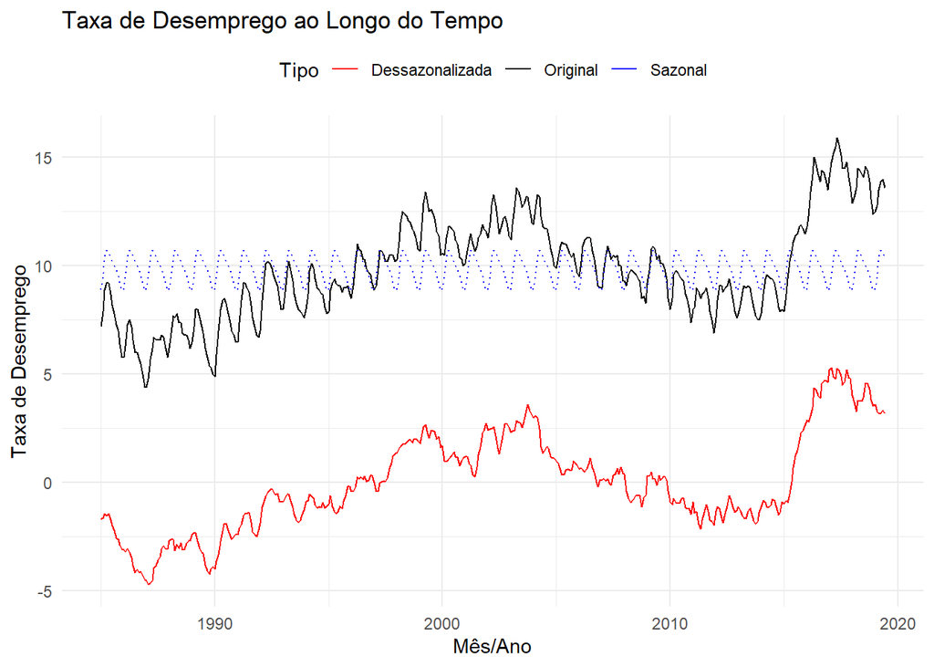

```r
ggplot(df, aes(x = `MesAno`)) +
  geom_line(aes(y = Desemprego, color = "Original"), size = 0.5, linetype = "solid") +
  geom_line(aes(y = Sazonal, color = "Sazonal"), size = 0.5, linetype = "dotted") +
  geom_line(aes(y = Dessazonalizada, color = "Dessazonalizada"), size = 0.5, linetype = "solid") +
  labs(title = "Taxa de Desemprego ao Longo do Tempo",
       y = "Taxa de Desemprego",
       x = "Mês/Ano",
       color = "Tipo") +
  scale_color_manual(values = c("Original" = "black", "Sazonal" = "blue", "Dessazonalizada" = "red")) +
  theme_minimal() +
  theme(legend.position = "top")
```